# A generic NOVA pass separates a DNT training set’s actives from its negative

EPA/Shafer multi-well MEA network formation assay (Brown et al. 2016) — exploratory reanalysis

Published

July 15, 2026

## Headline

NOVA’s standard pipeline was run over this dataset with no compound-specific tuning: normalise to same-plate vehicle controls, PCA, trajectory summary, rank by effect size. Brown et al. report that every compound in this training set except acetaminophen produced concentration-related effects.

**All 25 of the 25 largest changes are among the paper’s five actives, and acetaminophen appears 0 times.** The result does not depend on the curation rule below: on the filtered ranking it is 25 of 25 actives and 0 acetaminophen. 24 of the raw top 25 are decreases relative to vehicle.

This is a statement about **prediction, not neurotoxicity**, and a weaker one than it first looks (see the caveats): 20 of the raw top 25 are compounds the paper reports as cytotoxic, and the viability data that would separate “changed the network” from “killed the cells” is not in this file.

## Hero figure — the negative is flat, the actives are not

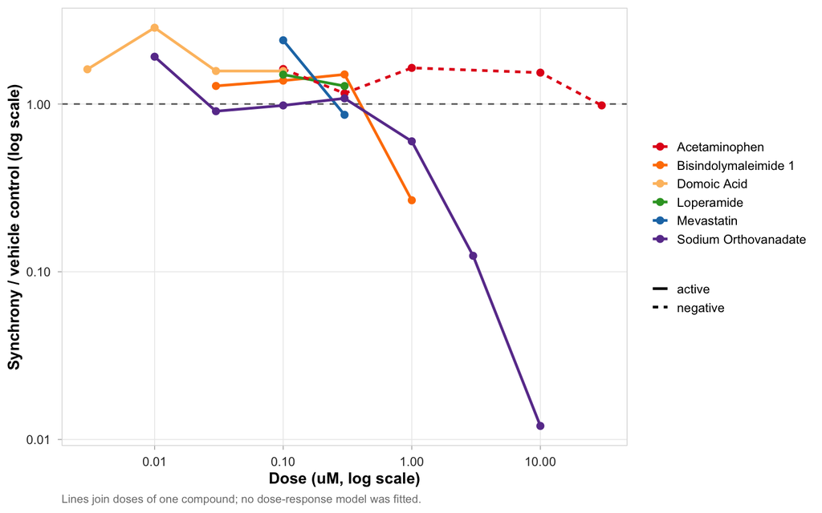

## The largest changes that more than one well agrees on

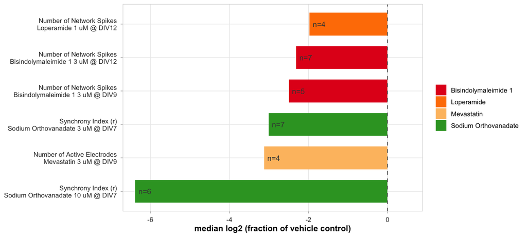

Top changes with at least 4 replicate wells, selected by effect-size rank from findings.csv rather than by eye. Bars are median log2 fold-change against same-plate vehicle controls – not against a baseline timepoint. Well counts are printed on each bar.

Top 6 changes with >= 4 wells, by effect size. ‘Cultures’ counts distinct (date, plate) experiments, of which there are 6 across 4 physical plates.

| Condition | Metric | DIV | vs control | Wells | Cultures |
| --- | --- | --- | --- | --- | --- |
| Sodium Orthovanadate 10 uM | Synchrony Index (r) | DIV7 | 83.44x down | 6 | 6 |
| Mevastatin 3 uM | Number of Active Electrodes | DIV9 | 8.70x down | 4 | 4 |
| Sodium Orthovanadate 3 uM | Synchrony Index (r) | DIV7 | 8.03x down | 7 | 6 |
| Bisindolymaleimide 1 3 uM | Number of Network Spikes | DIV9 | 5.64x down | 5 | 4 |
| Bisindolymaleimide 1 3 uM | Number of Network Spikes | DIV12 | 4.96x down | 7 | 6 |
| Loperamide 1 uM | Number of Network Spikes | DIV12 | 3.92x down | 4 | 4 |

## What the trajectory layer says, and why it misleads here

```
-- Trajectory summary --
  Across 45 conditions, 'Mevastatin 0.3 uM' moved farthest from baseline (6.85 PC units)
  and 'Mevastatin 30 uM' moved least (0.00).

  'Mevastatin 0.3 uM' moved 6.85 PC units from baseline via a fairly direct path.

  'Domoic Acid 0.03 uM' moved 3.71 PC units from baseline via a fairly direct path.

  'Domoic Acid 0.01 uM' moved 3.61 PC units from baseline via a fairly direct path.

  'Sodium Orthovanadate 0.03 uM' moved 3.07 PC units from baseline via a fairly direct
  path, with most of the change by DIV9.

  'Mevastatin 0.1 uM' moved 2.85 PC units from baseline via a fairly direct path.

  'Loperamide 1 uM' moved 2.55 PC units from baseline via a moderately direct path, with
  most of the change by DIV9.

  'Mevastatin 1 uM' moved 2.30 PC units from baseline via a fairly direct path.

  'Sodium Orthovanadate 0.1 uM' moved 2.16 PC units from baseline via a fairly direct path,
  with most of the change by DIV9.

  'Bisindolymaleimide 1 3 uM' moved 2.14 PC units from baseline via a fairly direct path.

  'Sodium Orthovanadate 3 uM' moved 2.13 PC units from baseline via a fairly direct path.

  'Loperamide 0.1 uM' moved 2.08 PC units from baseline via a fairly direct path.

  'Domoic Acid 1 uM' moved 2.06 PC units from baseline via a fairly direct path.

  'Acetaminophen 3 uM' moved 1.95 PC units from baseline via a fairly direct path.

  'Sodium Orthovanadate 0.3 uM' moved 1.82 PC units from baseline via a fairly direct path.

  'Domoic Acid 0.003 uM' moved 1.75 PC units from baseline via a fairly direct path.

  'Sodium Orthovanadate 0.01 uM' moved 1.63 PC units from baseline via a moderately direct
  path, peaking near DIV9 then partly returning toward baseline.

```

[output cut: 60 more lines]

```

  'Mevastatin (vehicle)' moved 0.17 PC units from baseline via a wandering path, with most
  of the change by DIV9.

  'Bisindolymaleimide 1 10 uM' moved 0.00 PC units from baseline via negligible movement,
  with most of the change by DIV7.

  'Loperamide 10 uM' moved 0.00 PC units from baseline via negligible movement, with most
  of the change by DIV7.

  'Loperamide 30 uM' moved 0.00 PC units from baseline via negligible movement, with most
  of the change by DIV7.

  'Mevastatin 30 uM' moved 0.00 PC units from baseline via negligible movement, with most
  of the change by DIV7.
```

Read this one carefully. `nova_trajectory_summary()` measures how far a condition travels through state space **between DIV 7 and DIV 12** — not how different it is from control. A compound that silences the network by DIV 7 and keeps it silent has a large effect and almost no trajectory, so the largest movers here are *low* doses, whose effect is still developing across the window. That is the metric behaving exactly as documented, answering a question this design does not ask.

The same applies to group separation: several fully-silenced conditions land on identical centroids, because everything at zero looks alike.

## Caveats

**Exploratory. Nothing here is a tested claim.**

- **The ranking is dominated by compounds the source reports as cytotoxic.** 20 of the raw top 25 are Bis-1, mevastatin or loperamide. Brown et al. single out **domoic acid and sodium orthovanadate** as the two that “altered several of these parameters in the absence of cytotoxicity” — the implication being that the others’ effects are at least partly cell death. The Cell Titer Blue viability data is **not in this file**, so this analysis cannot separate “changed the network” from “killed the cells”. “Recovers the training set’s actives” is therefore partly “recovers cytotoxicity”.
- **Fully-silenced wells are absent from the ranking.** A log-ratio cannot represent zero, so 1053 observations with a value of exactly 0 vs control are excluded — and those are the *largest possible* effects. 4 conditions disappear entirely as a result (Loperamide 10 uM; Loperamide 30 uM; Mevastatin 30 uM; Bisindolymaleimide 1 10 uM), which are top doses of three actives. The ranking therefore systematically under-represents complete network silencing. This is also why the trajectory section counts 45 conditions while the ranking sees 41.
- **Selection inflates the top of the list.** 944 condition × metric × timepoint comparisons were scanned and sorted by effect size; sorting a large family of noisy estimates puts the luckiest first. No correction is applied because nothing is a hypothesis test.
- **199 of 944 comparisons rest on fewer than 4 wells** and are excluded from the figures and table. Raw effect size cannot distinguish a large change in three wells from one in thirty: unfiltered, 14 of the top 25 rest on a **single well**. The largest single-well effect is 213x; the largest effect overall is 1680x, on 3 wells.
- **DIV 5 is excluded entirely.** Values are a fraction of same-plate vehicle controls, and at DIV 5 those controls are themselves silent: the control mean is exactly zero for network spikes in **5 of 6 experiments**, leaving the ratio undefined for **63–81% of wells on the network metrics** (0% on firing rate, active electrodes and synchrony). Cortical networks have not formed at DIV 5; that is what this assay measures.
- **No timepoint here is pre-treatment.** Compounds are applied from the start of the 12-day culture, so “change across DIV” is not “onset of effect”.
- **Plate, batch and dose structure are not modelled.** Wells nest in cultures, cultures reuse physical plates, doses nest in compounds, and DIV is a repeated measure on the same wells. Conditions are treated as flat groups.
- **Prediction is not causation.** Recovering the training set’s own active/inactive labels says the assay predicts those labels. It says nothing about developmental neurotoxicity in humans.
- **The burst-interval and network-spike *shape* metrics are excluded from the state space** (`mean.isis`, `mean.dur`, `mean.IBIs`, `ns.peak.m`, `ns.durn.m`, `ns.mean.insis`, `ns.durn.sd`, `ns.mean.spikes.in.ns`), because their 33–42% missingness means “this well did not burst” rather than “measurement lost”, and mean-imputing would invent burst statistics for silent wells. The network-spike **counts** (`ns.n`, `ns.percent.of.spikes.in.ns`) have no missingness and *are* in the state space.

# Source <80><94> EPA/Shafer MEA developmental neurotoxicity screen (Brown et al. 2016)

| Field | Value |
| --- | --- |
| Dataset | Data for Brown et al MEA Developmental Neurotoxicity Screening Manuscript |
| Catalog | https://catalog.data.gov/dataset/data-for-brown-et-al-mea-developmental-neurotoxicity-screening-manuscript |
| File URL | https://pasteur.epa.gov/uploads/10.23719/1412682/Final_Data_Set_SA1_DNT_Paper1%20%282%29%28updated%29_CF.csv |
| Local file | `data/brown2016_mea_dnt.csv` (gitignored) |
| Size | 210,268 bytes |
| SHA-256 | `80522f6654012a18851ad17f180f51d98df6b84ab122078ce303c4d3c079f43a` |
| Downloaded | 2026-07-14 |
| Server Last-Modified | 2017-12-24 |
| Licence | US Government work <80><94> public domain, 17 U.S.C. 105. Verified on the EPA ScienceHub licence page: no attribution or redistribution conditions; EPA disclaims warranty as to accuracy, and its seal … |
| Publisher | U.S. EPA Office of Research and Development (ORD) |
| Contact | Timothy Shafer (shafer.tim@epa.gov) |
| Publication | Brown J, Hall D, Frank C, Wallace K, Mundy W, Shafer T (2016). “Evaluation of a Microelectrode Array-based Assay for Neural Network Ontogeny using Training Set Chemicals.” *Toxicological Sciences* 154… |
| Instrument | Axion Maestro, 48-well MEA plates |

**Publisher’s own note, carried forward:** “These data are the individual parameter and well-level data that were support the conclusions in Brown et al. Note: the parameters CVtime and CVnetwork were not used.” <86><92> `cv.time` and `cv.network` are therefore **excluded**.

## Verified structure

Confirmed by inspecting the downloaded file, not inferred from the paper.

- **990 rows <97> 26 columns**, wide: one row per well <97> DIV, metrics as columns.
- **6 experiments**, being 6 unique `(date, Plate.SN)` pairs <80><94> see the identity note below.
- **256 wells** (unique `date <c3><97> Plate.SN <c3><97> well`); 48 well IDs per plate (A1<80>).
- **4 timepoints**: DIV 5, 7, 9, 12. 222 wells have all four, 34 have three (990 = 222<97>4 + 34<97>3).
- **7 compounds**, each well carrying exactly one compound at one dose for the whole run (12-day exposure). Doses: 0, 0.003, 0.01, 0.03, 0.1, 0.3, 1, 3, 10, 30 M. `dose = 0` is that compound’s vehicle control.
- **6 culture dates** (batches): 20140205, 20140212, 20140402, 20140423, 20140716, 20140730.
- No duplicate `(well, DIV)` rows.

### Identity: `Experiment` must be `(date, Plate.SN)`, not `Plate.SN`

`Plate.SN` is a **physical plate serial number, and plates are reused across culture dates** <80><94> MW1007-26 and MW1007-27 each appear on two dates. There are 4 serial numbers but 6 actual experiments.

Mapping `Experiment = Plate.SN` would merge well A1 of MW1007-26 on 2014-02-05 with well A1 of MW1007-26 on 2014-02-12: two different cultures, one identity. That is exactly the cross-plate collision NOVA 0.4.0 fixed, reintroduced through the adapter. `Experiment = paste(date, Plate.SN)`.

### Metrics (16 usable)

`meanfiringrate`, `burst.per.min`, `mean.isis`, `per.spikes.in.burst`, `mean.dur`, `mean.IBIs`, `nAE`, `nABE`, `ns.n`, `ns.peak.m`, `ns.durn.m`, `ns.percent.of.spikes.in.ns`, `ns.mean.insis`, `ns.durn.sd`, `ns.mean.spikes.in.ns`, `r`.

### DIV 5 cannot serve as a normalisation baseline

At DIV 5, a large share of wells read exactly zero:

| Metric | Zero at DIV 5 | Median at DIV 5 |
| --- | --- | --- |
| `ns.n` (network spikes) | 236/256 (92.2%) | 0 |
| `burst.per.min` | 168/256 (65.6%) | 0 |
| `r` (synchrony) | 112/256 (43.8%) | 0 |
| `meanfiringrate` | 107/256 (41.8%) | 0.21 |
| `nAE` (active electrodes) | 107/256 (41.8%) | 1 |

This is the assay working as intended <80><94> cortical networks are near-silent at DIV 5 and develop activity through DIV 12; that development *is* the measured phenomenon. But it means a fold-change against DIV 5 divides by zero for 42<80><93>92% of wells, which NOVA correctly returns as `NA`. Baseline-normalising to the earliest DIV would discard most of the dataset and keep a biased remnant: precisely the wells that were already active at DIV 5.

**The Phase-0 assumption “baseline = earliest DIV” does not hold for this dataset.**

## What the source paper designates active

Quoted from the abstract of Brown et al. (2016), *Toxicol Sci* 154(1):126<80><93>139 ([doi:10.1093/toxsci/kfw147](https://doi.org/10.1093/toxsci/kfw147), [PMID 27492221](https://pubmed.ncbi.nlm.nih.gov/27492221/)) <80><94> **verified against the abstract, not inferred**:

> “All compounds except acetaminophen (<89> 30 M) caused concentration-related effects on one or more of these parameters.”

> “Domoic acid and sodium orthovanadate altered several of these parameters in the absence of cytotoxicity.”

So the training set is **five actives and one negative**, and among the actives the paper draws a second, load-bearing distinction:

| Compound | Designation | Basis |
| --- | --- | --- |
| Acetaminophen | **negative** (<89> 30 M) | “All compounds except acetaminophen<80>” |
| Domoic acid | active, **without cytotoxicity** | named explicitly |
| Sodium orthovanadate | active, **without cytotoxicity** | named explicitly |
| Bisindolylmaleimide-1 | active | “all compounds except acetaminophen” |
| Mevastatin | active | as above |
| Loperamide | active | as above |
| Glyphosate | <80><94> | not in the paper’s training set; appears here at dose 0 only |

**The cytotoxicity distinction matters for interpretation.** The paper singles out domoic acid and sodium orthovanadate as altering network parameters *without* killing cells. The implication for the other three actives is that their network effects are at least partly cytotoxic. Viability (Cell Titer Blue, day 12) is **not in this file**, so cytotoxicity cannot be modelled or adjusted for here <80><94> an activity ranking built on this file alone cannot separate “changed the network” from “killed the cells”, and must say so.

## Caveats to carry into any analysis

- **DIV 5 is already exposed.** Compounds are applied from the start of the 12-day culture, so no timepoint here is pre-treatment. “Change from DIV 5” is not “effect of compound”.
- **Dose is nested within compound** and the discovery engine treats groups as flat.
- **DIV is a repeated measure** on the same wells; unmodelled.
- **Plate and batch structure**: wells nested in plates, plates nested in culture dates, and plate serial numbers reused across dates. Unmodelled.
- **Glyphosate appears only at dose 0** (14 rows, no treated wells in this file) <80><94> it cannot support a dose-response and should not be read as a tested negative here.
- “Separates neuroactive from inactive” would be a statement about prediction, not about neurotoxicity in vivo.

Generated with [NOVA](https://github.com/atudoras/nova) 0.5.0. Discovery pass: `run_discovery.R`. Figures use `nova_theme()`/`nova_palette()`. Every result shown was selected by effect-size rank from `findings.csv`; none was hand-picked.